# HW 1

SDS348 Fall 2020

September 02, 2020

#### Arun Krishnaraj (ak37738)

**This homework is due on Sep 6, 2020 at 11:59pm. Please submit as an HTML file on Canvas.**

*For all questions, include the R commands/functions that you used to find your answer. Answers without supporting code will not receive credit.*

##### How to submit this assignment

> All homework assignments will be completed using R Markdown. These `.Rmd` files consist of text/syntax (formatted using Markdown) alongside embedded R code. When you have completed the assignment (by adding R code inside codeblocks and supporting text outside codeblocks), create your document as follows:
> - Click the “Knit” button (above)
> - Fix any errors in your code, if applicable
> - Upload the HTML file to Canvas

## Q1 (1 pts)

##### The dataset `quakes` contains information about earthquakes occurring near Fiji since 1964. The first few observations are listed below.

```r
head(quakes)
```

```
##      lat   long depth mag stations
## 1 -20.42 181.62   562 4.8       41
## 2 -20.62 181.03   650 4.2       15
## 3 -26.00 184.10    42 5.4       43
## 4 -17.97 181.66   626 4.1       19
## 5 -20.42 181.96   649 4.0       11
## 6 -19.68 184.31   195 4.0       12
```

##### How many observations are there of each variable (i.e., how many rows are there; show using code)? How many variables are there total (i.e., how many columns are in the dataset)? You can read more about the dataset [here](https://stat.ethz.ch/R-manual/R-patched/library/datasets/html/quakes.html) *Do not forget to include the code you used to find the answer each question*

```r
nrow(quakes)
```

```
## [1] 1000
```

```r
ncol(quakes)
```

```
## [1] 5
```

There are 1000 observation of each variable, reflected by the number of rows in the dataset. There are 5 variables in the dataset, reflected by the number of columns in the dataset.

## Q2 (2 pts)

##### What are the minimum, maximum, mean, and median values for the variables `mag` and `depth`? Note that there are many functions that can be used to answer this question. If you chose to work with each variable separately, recall that you can access individual variables in a dataframe using the `$` operator (e.g., `dataset$variable`). Describe your answer in words.

```r
summary(quakes$mag)
```

```
##    Min. 1st Qu.  Median    Mean 3rd Qu.    Max.
##    4.00    4.30    4.60    4.62    4.90    6.40
```

```r
summary(quakes$depth)
```

```
##    Min. 1st Qu.  Median    Mean 3rd Qu.    Max.
##    40.0    99.0   247.0   311.4   543.0   680.0
```

The magnitude variable has a minimum of 4.0, maximum of 6.4, with a mean of 4.62 and median of 4.6 on the Richter Scale. The depth variable has a minimum of 40.0, maximum of 680.0, with a mean of 311.4 and a median of 247.0 kilometers.

## Q3

##### Recall how logical indexing of a dataframe works in R. To refresh your memory, in the example code below I ask R for the median magnitude for quakes whose longitude is greater than 175. The two ways produce equivalent results.

```r
median(quakes$mag[quakes$long>175])
```

```
## [1] 4.5
```

```r
median(quakes[quakes$long>175,]$mag) #this is the more conventional notation
```

```
## [1] 4.5
```

### 3.1 (1 pt)

##### Explain what each of the two lines of code are doing in words. Specifically, why do we need to use the comma in the second case but not in the first? Remember that the `$` selects a single variable and that `[ ]` are used for indexing whatever object came before (either a single variable or a dataframe).

The first line initially returns a logical index of observations where the variable longitude is greater than 175; this logical index is then used to index the magnitude column of the dataset, which returns only magnitude values where the respective longitude value is greater than 175. The second line initially also returns a logical index where the variable longitude is greater than 175. Using `[ ]` indexing, the logical index is used to index rows, and the empty column index argument results in complete observations where longitude value is greater than 175 being returned; the magnitude column is then selected using `$` variable selection.

### 3.2 (3 pts)

##### What is the mean of the variable `mag` when `depth` is *greater than* the median depth? What is the mean of the variable `mag` when `depth` is *less than* the median depth? What does this suggest about the relationship between an earthquake’s depth and its magnitude?

```r
mean(quakes$mag[quakes$depth > median(quakes$depth)])
```

```
## [1] 4.5232
```

```r
mean(quakes$mag[quakes$depth < median(quakes$depth)])
```

```
## [1] 4.7176
```

When `depth` is greater than the median depth, the mean value of `mag` is 4.5232; When `depth` is less than the median depth, the mean value of `mag` is 4.7176. This suggests that there may be an inverse relationship between magnitude and depth; as depth increases, it’s possible that the magnitude of the quake decreases.

### 3.3 (2 pts)

##### What is the standard deviation of the variable `lat` when `depth` is *greater than* the median depth? What is the standard deviation of the variable `lat` when `depth` is *less than* the median depth? What does this suggest about the relationship between an earthquake’s latitude and it’s depth?

```r
sd(quakes$lat[quakes$depth > median(quakes$depth)])
```

```
## [1] 3.577252
```

```r
sd(quakes$lat[quakes$depth < median(quakes$depth)])
```

```
## [1] 6.1501
```

When `depth` is greater than the median depth, the standard deviation of `lat` is 3.577252. When `depth` is less than the median depth, the standard deviation of `lat` is 6.1501. This suggests that earthquakes of higher depth tend to be more tightly clustered in latitude than earthquakes of lower depth.

## Q4 (2 pts)

##### The variable `depth` is measured in kilometers. Create a new variable called `depth_m` that gives depth **in meters rather than kilometers** and add it to the dataset `quakes`. To help get you started, I have given you code that creates the new variable but fills it with `NA` values. Overwrite the `NA`s below by writing code on the left-hand side of the assignment operator (`<-`) that computes the requested transformation. Print out the first few rows of the updated dataset using `head()`.

```r
# update the code below by replacing the NA with the correct expression to convert to meters
quakes$depth_m <- quakes$depth * 1000
head(quakes)
```

```
##      lat   long depth mag stations depth_m
## 1 -20.42 181.62   562 4.8       41  562000
## 2 -20.62 181.03   650 4.2       15  650000
## 3 -26.00 184.10    42 5.4       43   42000
## 4 -17.97 181.66   626 4.1       19  626000
## 5 -20.42 181.96   649 4.0       11  649000
## 6 -19.68 184.31   195 4.0       12  195000
```

## Q5

##### Let’s make some plots in base R.

### 5.1 (2 pt)

##### Create a boxplot of `depth` using the `boxplot()` function. Describe where you see the min, max, and median (which you calculated in question 2) in this plot.

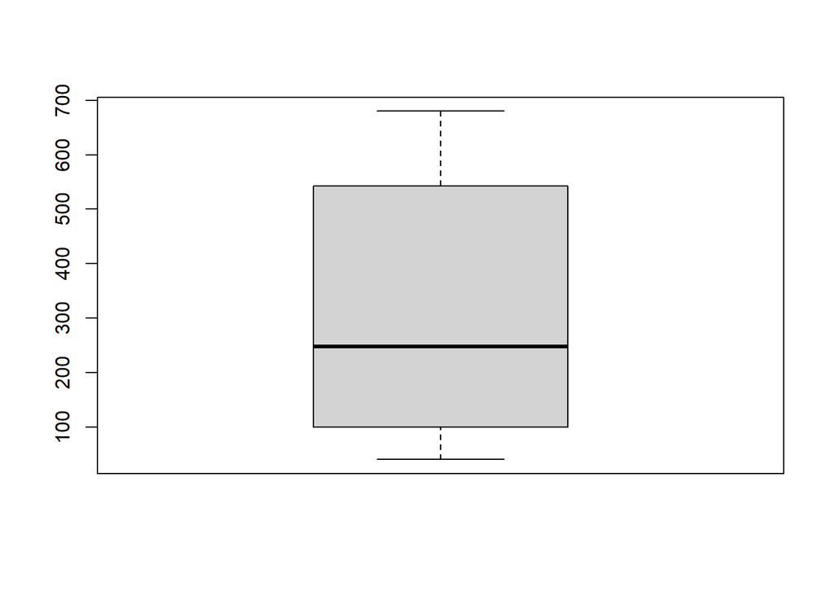

```r
boxplot(quakes$depth)
```

We can see the median of 247 km as the thick horizontal line near the center of the boxplot. The maximum of 680 and the minimum of 40 km appear as the horizontal lines at the end of the top and bottom “whiskers” respectively.

### 5.2 (2 pt)

##### Create a histogram of `depth` using the `hist()` function. What important information does the histogram provide that the boxplot does not?

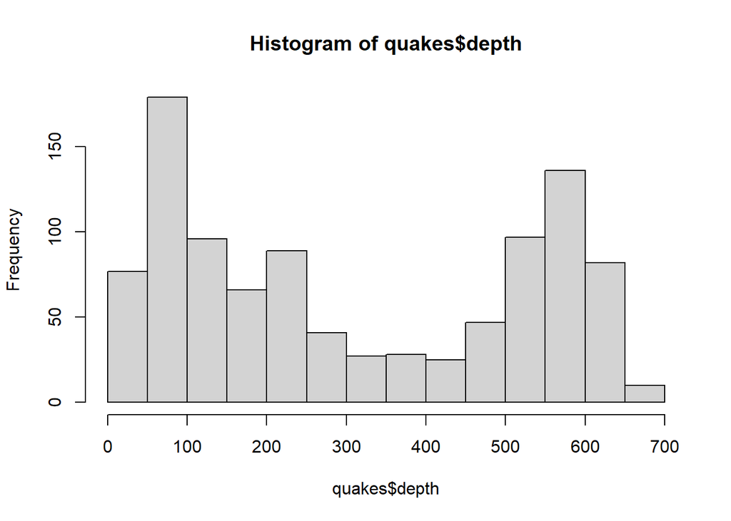

```r
hist(quakes$depth)
```

The histogram shows that the distribution of quake depth seems to be bimodal; there are fewer number of observations with depth values near the median, and more near the maximum and minimum depth values.

### 5.3 (2 pt)

##### Create a scatterplot by plotting variables `mag` and `stations` against each other using the `plot()` function. Note that to generate a scatterplot, the `plot()` takes two arguments: the x-axis variable and the y-axis variable. Describe the relationship between the two variables.

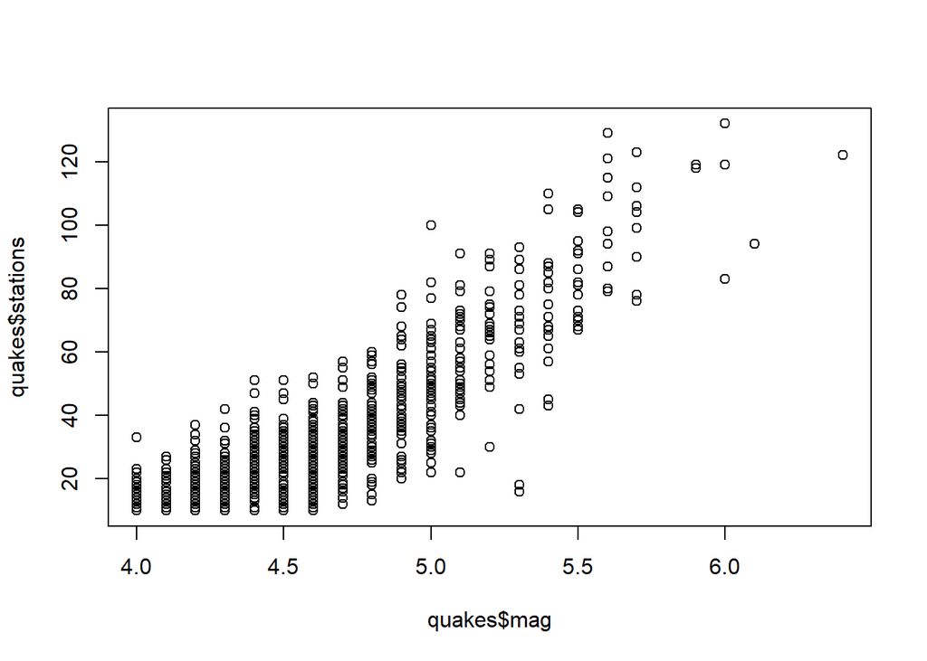

```r
plot(quakes$mag, quakes$stations)
```

There seems to be a positive linear relationship between earthquake magnitude and number of stations recorded. There are also fewer high magnitude and high station number observations.

### 5.4 (3 pt)

##### Create scatterplot of the quakes’ geographic locations by plotting `long` on the x-axis and `lat` on the y-axis. Using this plot, and the map/link below (note the two trenches), and some of the techniques you practiced above, are deeper quakes more likely to originate east or west of Fiji?

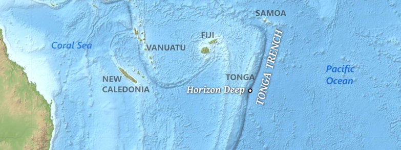

[Link to location on Google maps](https://www.google.com/maps/@-20.1679389,175.7587479,3513560m/data=!3m1!1e3)

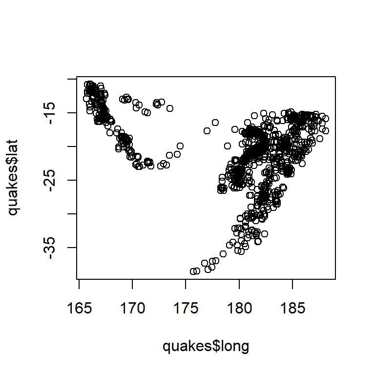

```r
plot(quakes$long, quakes$lat)
```

```r
## From Google Maps, the center of Fiji is -17.72, 178.01
summary(quakes$depth[quakes$long > 178.01]) ## East of Fiji
```

```
##    Min. 1st Qu.  Median    Mean 3rd Qu.    Max.
##    40.0   123.0   386.5   349.7   559.0   680.0
```

```r
summary(quakes$depth[quakes$long < 178.01]) ## West of Fiji
```

```
##    Min. 1st Qu.  Median    Mean 3rd Qu.    Max.
##    40.0    69.0   131.0   170.5   212.5   663.0
```

```r
nrow(quakes[quakes$long > 178.01,])
```

```
## [1] 786
```

```r
nrow(quakes[quakes$long < 178.01,])
```

```
## [1] 214
```

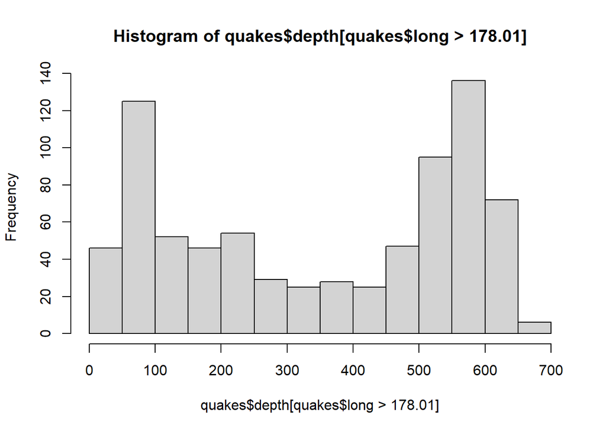

```r
hist(quakes$depth[quakes$long > 178.01])
```

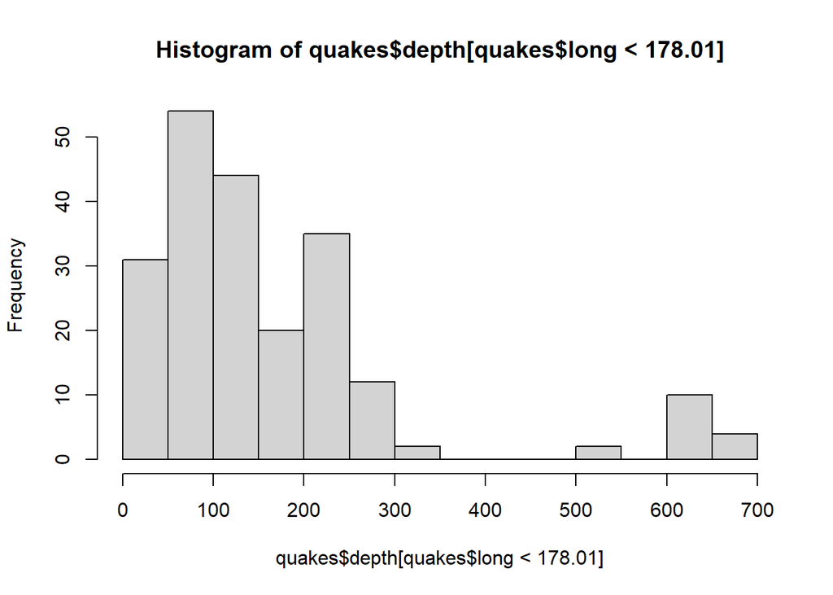

```r
hist(quakes$depth[quakes$long < 178.01])
```

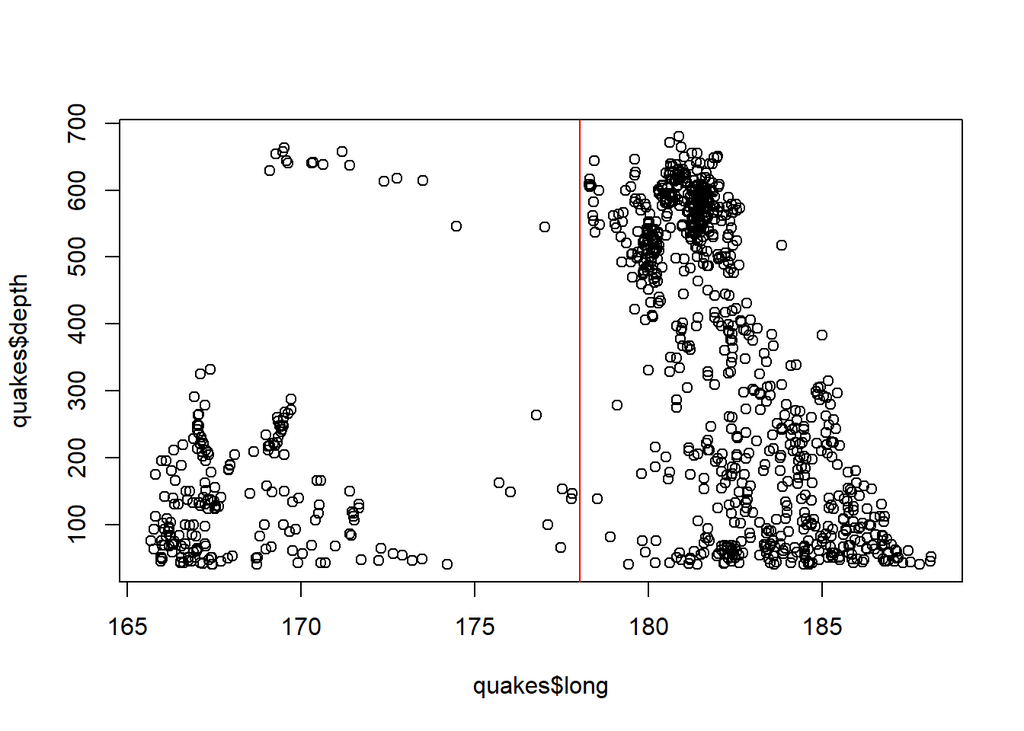

```r
plot(quakes$long,quakes$depth); abline(v = 178.01, col = "red")
```

From this data, it seems like earthquakes to the East of Fiji have a significantly higher mean and median depth; Eastern earthquakes have a median and mean depth of 386.5 and 349.7 km respectively, while Western earthquakes have a median and mean depth of 131 and 170.5 km respectively. There were 786 earthquakes East of Fiji, and 214 earthquakes West of Fiji since 1964. Both East and West depth histograms indicate lower number of earthquakes with near-median depth; Eastern earthquakes have a higher proportion of high-depth quakes than the West, and exhibit stronger bimodality. The scatterplot of earthquake depth vs longitude reflects no clear linear relationship, but clearly demonstrates the bimodality of Eastern quakes. This suggests that deeper and overall more quakes are likely to originate in the East.

```
## [1] "2020-09-02 20:24:21 CDT"
```

[output not shown]